# Communicating with Data in the Tidyverse

2021-09-09

```r
library(tidyverse)
ilo_hourly_compensation <- read.csv("ilo_hourly_compensation.csv")
ilo_working_hours <- read.csv("ilo_working_hours.csv")
```

## 1-2 Join the two data sets together

In the video, you have learned that the inner_join() function of dplyr needs to be given a “key” on which two data frames are joined. Actually, multiple keys that need to match can be specified. In this first exercise, you are going to join two data sets by two keys. The data frames ilo_hourly_compensation and ilo_working_hours are already loaded for you and are available in your workspace.

This course touches on a lot of concepts you may have forgotten, so if you ever need a quick refresher, download the tidyverse Cheat Sheet and keep it handy!

```r
# Join both data frames
ilo_data <- ilo_hourly_compensation %>%
  inner_join(ilo_working_hours, by = c("country", "year"))

# Count the resulting rows
ilo_data  %>%
    count()

# Examine ilo_data
ilo_data
```

[output not shown]

## 1-3 Change variable types

```r
# Turn year and country into a factor
ilo_data_corrected <- ilo_data %>%
  mutate(year = as.factor(as.numeric(year)),
        country = as.factor(country))

# See the results
ilo_data_corrected
```

```
##              country year hourly_compensation working_hours
## 1          Australia 1980                8.44      34.57885
## 2             Canada 1980                8.87      34.85000
## 3            Denmark 1980               10.83      31.89808
## 4            Finland 1980                8.61      35.56346
## 5             France 1980                8.90      35.42308
## 6              Italy 1980                8.09      35.74635
## 7              Japan 1980                5.46      40.78846
## 8        Korea, Rep. 1980                0.95      55.30769
## 9             Norway 1980               11.80      30.37885
## 10             Spain 1980                5.86      36.77692
## 11            Sweden 1980               12.40      29.16923
## 12       Switzerland 1980               10.96      34.70385
## 13    United Kingdom 1980                7.52      34.08654
## 14     United States 1980                9.63      34.80769
```

[output cut: 237 more lines]

## 1-5 Filter the data for plotting

Use the filter() function of dplyr to remove non-European countries. A vector called european_countries has been created that contains all European countries which should remain in the data set. Here, the %in% operator introduced in the video might come in handy. Note that only a subset of European countries for which enough data exist is retained. For instance, Poland is missing.

```r
european_countries <- c("Finland", "France", "Italy", "Norway", "Spain", "Sweden", "Switzerland", "United Kingdom", "Belgium", "Ireland", "Luxembourg", "Portugal", "Netherlands", "Germany", "Hungary", "Austria", "Czech Rep.")

# Examine the European countries vector
european_countries
```

```
##  [1] "Finland"        "France"         "Italy"          "Norway"
##  [5] "Spain"          "Sweden"         "Switzerland"    "United Kingdom"
##  [9] "Belgium"        "Ireland"        "Luxembourg"     "Portugal"
## [13] "Netherlands"    "Germany"        "Hungary"        "Austria"
## [17] "Czech Rep."
```

```r
# Only retain European countries
ilo_data <- ilo_data %>%
  filter(country %in% european_countries)
```

## 1-6 Some summary statistics

```r
# Examine the structure of ilo_data
str(ilo_data)
```

```
## 'data.frame':    380 obs. of  4 variables:
##  $ country            : chr  "Finland" "France" "Italy" "Norway" ...
##  $ year               : int  1980 1980 1980 1980 1980 1980 1980 1980 1981 1981 ...
##  $ hourly_compensation: num  8.61 8.9 8.09 11.8 5.86 ...
##  $ working_hours      : num  35.6 35.4 35.7 30.4 36.8 ...
```

```r
# Group and summarize the data
ilo_data %>%
  group_by(year) %>%
  summarize(mean_hourly_compensation = mean(hourly_compensation),
            mean_working_hours = mean(working_hours))
```

```
## # A tibble: 27 x 3
##     year mean_hourly_compensation mean_working_hours
##    <int>                    <dbl>              <dbl>
##  1  1980                     9.27               34.0
##  2  1981                     8.69               33.6
##  3  1982                     8.36               33.5
##  4  1983                     7.81               33.9
##  5  1984                     7.54               33.7
##  6  1985                     7.79               33.7
##  7  1986                     9.70               34.0
##  8  1987                    12.1                33.6
##  9  1988                    13.2                33.7
## 10  1989                    13.1                33.5
## # ... with 17 more rows
```

## 1-7 A basic scatter plot

In this exercise, you will create a very basic scatter plot with ggplot2. This is mostly a repetition of stuff you’ve learnt in the prerequisites for this course, so it should be easy for you.

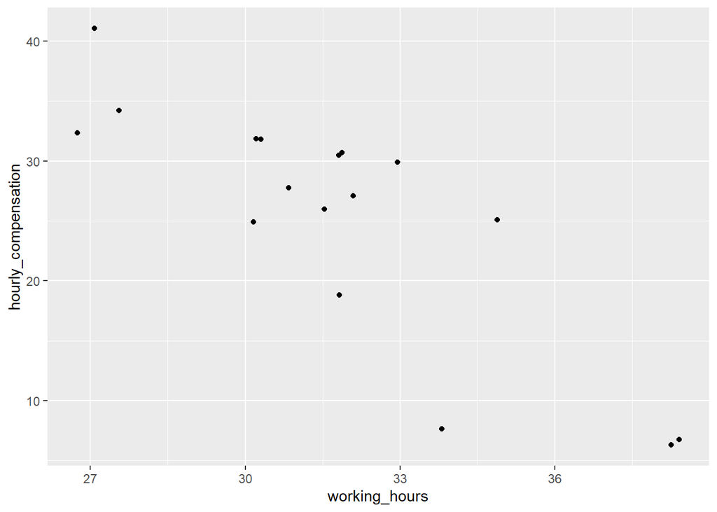

```r
# Filter for 2006
plot_data <- ilo_data %>%
  filter(year==2006)

# Create the scatter plot
ggplot(plot_data) +
  geom_point(aes(x = working_hours, y = hourly_compensation))
```

## 1-8 Add labels to the plot

As mentioned in the video, you’re going to enhance the plot from the previous exercise by adding a title, a subtitle, and a caption to the plot as well as giving the axes meaningful names. You’re going to use the labs() function to do this – try using ?labs in the console to see the available options.

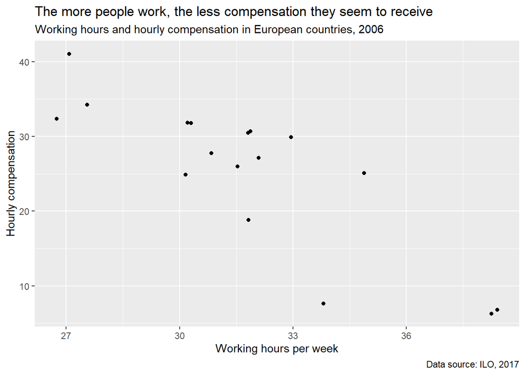

```r
# Create the plot
ggplot(plot_data) +
  geom_point(aes(x = working_hours, y = hourly_compensation)) +
  # Add labels
  labs(
    x = "Working hours per week",
    y = "Hourly compensation",
    title = "The more people work, the less compensation they seem to receive",
    subtitle = "Working hours and hourly compensation in European countries, 2006",
    caption = "Data source: ILO, 2017"
  )
```

## 1-10 Apply a default theme

As you’ve learnt in the videos, ggplot2 comes with a set of predefined themes. Try out some of them!

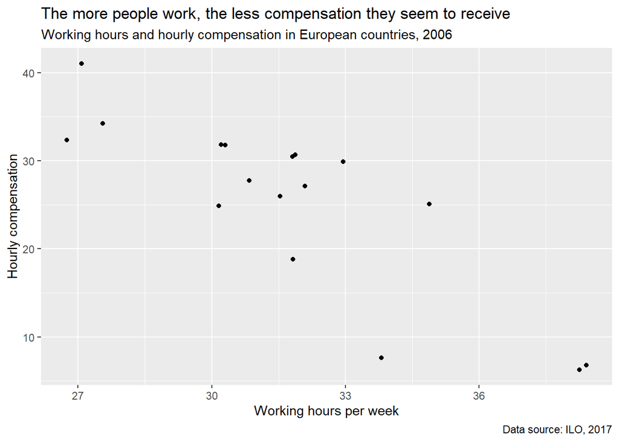

```r
# Save your current plot into a variable: ilo_plot
ilo_plot <- ggplot(plot_data) +
  geom_point(aes(x = working_hours, y = hourly_compensation)) +
  labs(
    x = "Working hours per week",
    y = "Hourly compensation",
    title = "The more people work, the less compensation they seem to receive",
    subtitle = "Working hours and hourly compensation in European countries, 2006",
    caption = "Data source: ILO, 2017"
  )

ilo_plot
```

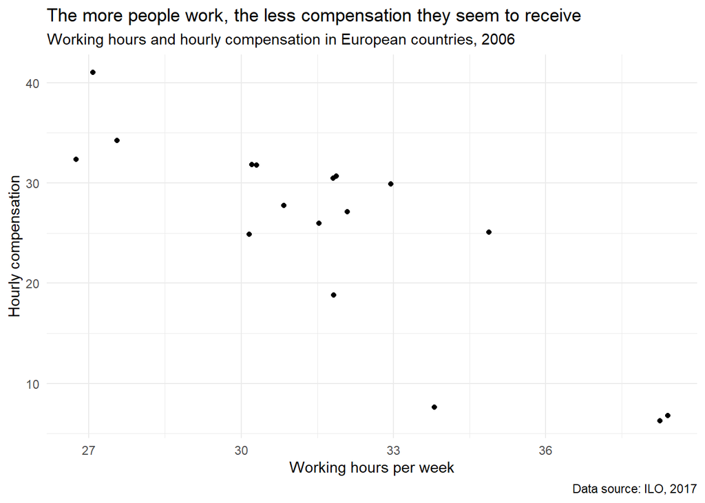

```r
ilo_plot +
  theme_minimal()
```

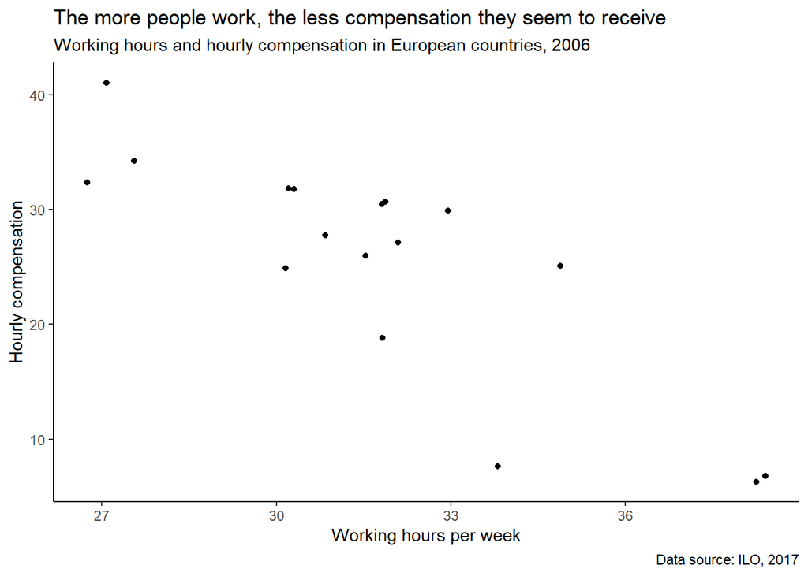

```r
ilo_plot +
  theme_classic()
```

## 1-11 Change the appearance of titles

Besides applying defined theme presets, you can tweak your plot even more by altering different style attributes of it. Hint: You can reuse and overwrite the ilo_plot variable generated in the previous exercise – the current plot is already shown in the window on the right.

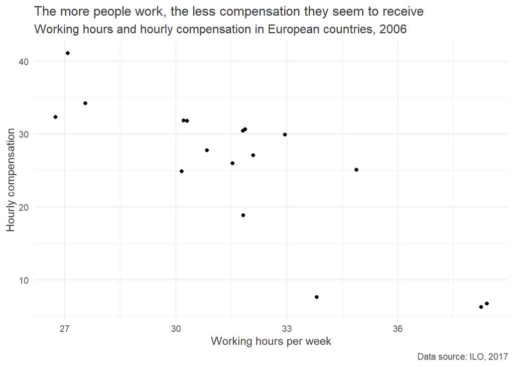

```r
ilo_plot <- ilo_plot +
  theme_minimal() +
  # Customize the "minimal" theme with another custom "theme" call
  theme(
    text = element_text(family = "Bookman"),
    title = element_text(color = "gray25"),
    plot.caption = element_text(color = "gray30"),
    plot.subtitle = element_text(size = 12)
  )

# Render the plot object
ilo_plot
```

## 1-12 Alter background color and add margins

Further customize the look of your plot with more arguments to the theme function call. You can continue working on your ilo_plot object created in the last exercise.

Add margins to the plot: 5mm top and bottom, 10mm to the left and the right.

The margins need to be specified in the following order: top, right, bottom, and left.

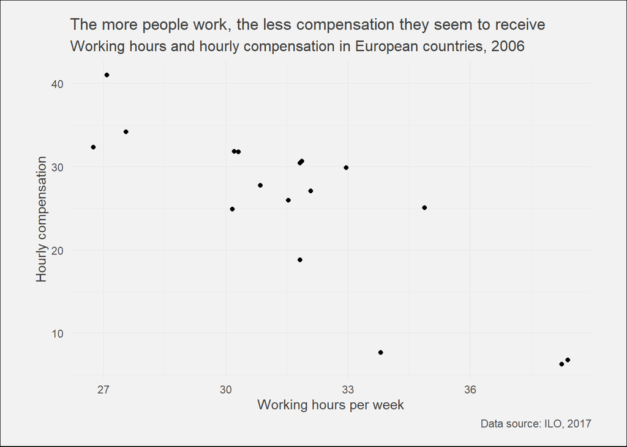

```r
ilo_plot +
  # "theme" calls can be stacked upon each other, so this is already the third call of "theme"
  theme(
    plot.background = element_rect(fill = "gray95"),
    plot.margin = unit(c(5, 10, 5, 10), units = "mm")
  )
```